# Fitting LMEs to ERP Data: Auditory Oddball (MMN) Walkthrough

Single-trial MMN difference waves

2026-10-12

# 1 Overview

In this example, we’ll walk through the 9 steps to building an LME with a second ERP paradigm: an **auditory oddball**, in which participants hear a frequent **standard** sound and a rare **deviant** sound.

Following the difference-wave section of the workshop, we model the mismatch negativity (MMN) **trial by trial**: each deviant is paired with the standard immediately before it, and the outcome is their difference, a **single-trial MMN difference wave** (as in Mon et al., 2024).

Compared with the face-emotion example (Example 1), this dataset models a difference wave as an outcome and arrives at a different random effects specification at the end of the model simplification processs.

A separate supplement (`LME_ex2_supplement_interaction.Rmd`) fits the same data a second way, as a **Condition × Age interaction** on the standard and deviant amplitudes (Heise et al., 2025), and compares the two approaches.

# 2 Simulating an Oddball Study

## 2.1 Study design

**Our simulation** is loosely based on oddball designs like those in Mon et al. (2024) and Coy et al. (2024):

- **Participants:** 40, aged 2 to 4 years
- **Stimuli:** a standard syllable /ba/ and a deviant /da/, with the deviant recorded by 6 speakers (6 **recordings/speakers**, or “tokens”)
- **Trials:** 600 standards and 150 deviants (25 per token) per participant
- **Outcome:** a single-trial MMN for every deviant: the deviant minus the standard right before it

The population values for the MMN come from Coy et al. (2024, Table 1):

- Standard: ~**1.9 µV**; deviant: ~**0 µV**, so the MMN is ~**−1.9 µV**
- SD of the MMN across participants: 0.148 × √60 ≈ **1.15 µV**
- SD of the standard amplitude across participants: 0.187 × √60 ≈ **1.45 µV**

The additional parameters (habituation, the token and age effects, and the single-trial noise) are our own choices.

```r
# Study design parameters --------------------------------------------------
n_subjects     <- 40     # number of participants
n_tokens       <- 6      # recordings/speakers of the deviant /da/
dev_per_token  <- 25     # deviants per token per participant
n_deviant      <- n_tokens * dev_per_token   # 150 deviants per participant
n_standard     <- 4 * n_deviant              # 600 standards per participant (80% of trials)

# Population-level parameters (MMN size and variability from Coy et al., 2024) --
mean_amp_standard <- 1.9    # mean amplitude for standards (µV)
mmn_effect        <- -1.9   # MMN (deviant - standard) at the middle of the session (µV)
subject_int_sd    <- 1.45   # SD of participants' standard amplitude
subject_mmn_sd    <- 1.15   # SD of participants' MMN (random intercept in the MMN model)
int_mmn_cor       <- -0.3   # correlation between participants' standard amplitude and MMN

# Additional parameters ---------------------------------------------------------
hab_effect        <- 0.15   # MMN becomes less negative by this much per 10 deviants (habituation)
subject_hab_sd    <- 0.2    # participants habituate at different rates (SD per 10 deviants)
age_effect        <- -0.5   # MMN becomes more negative by this much per year of age
token_sd          <- 0.5    # some /da/ recordings/speakers elicit a larger MMN than others
trial_noise_sd    <- 7      # single-trial noise SD (each trial, standard or deviant)

set.seed(2026)
```

## 2.2 Building the trial-level dataset

Each simulated participant hears a sequence in which every deviant follows at least two standards (so every deviant has a standard right before it, as in typical oddball designs). Each simulated participant gets their own standard amplitude, MMN size, and habituation rate, and each /da/ token has its own MMN shift.

```r
subject_ids <- sprintf("%02d", 1:n_subjects)

# Participant-level random effects: correlated standard amplitude + MMN, habituation rate, age
re_cov <- matrix(c(subject_int_sd^2,
                   int_mmn_cor * subject_int_sd * subject_mmn_sd,
                   int_mmn_cor * subject_int_sd * subject_mmn_sd,
                   subject_mmn_sd^2), nrow = 2)
subject_re <- MASS::mvrnorm(n_subjects, mu = c(0, 0), Sigma = re_cov) %>%
  as_tibble(.name_repair = ~ c("subj_intercept", "subj_mmn")) %>%
  mutate(SubjectID = subject_ids,
         subj_hab  = rnorm(n_subjects, 0, subject_hab_sd),
         AgeYears  = round(runif(n_subjects, 2, 4), 1))

# Token-level random effects
token_re <- tibble(Token = paste0("da", 1:n_tokens),
                   token_mmn = rnorm(n_tokens, 0, token_sd))

# One participant's sequence: each deviant follows at least 2 standards; the remaining
# standards are spread at random, and the 6 tokens appear in random order
make_sequence <- function() {
  extra <- as.vector(rmultinom(1, n_standard - 2 * n_deviant, rep(1, n_deviant)))
  tokens <- sample(rep(paste0("da", 1:n_tokens), dev_per_token))
  map2_dfr(2 + extra, seq_len(n_deviant), function(k, i)
    tibble(Condition = c(rep("Standard", k), "Deviant"),
           Token     = c(rep(NA, k), tokens[i])))
}

oddball_data <- map_dfr(subject_ids, ~ make_sequence() %>% mutate(SubjectID = .x)) %>%
  group_by(SubjectID) %>%
  mutate(TrialNum = row_number(),
         DevNum   = if_else(Condition == "Deviant", cumsum(Condition == "Deviant"), NA_integer_)) %>%
  ungroup() %>%
  left_join(subject_re, by = "SubjectID") %>%
  left_join(token_re, by = "Token") %>%
  mutate(
    # the MMN on this deviant: average MMN + participant + habituation + age + token
    mmn = if_else(Condition == "Deviant",
                  mmn_effect + subj_mmn +
                    (hab_effect + subj_hab) * (DevNum - mean(1:n_deviant)) / 10 +
                    age_effect * (AgeYears - 3) + token_mmn,
                  0),
    MeanAmp   = mean_amp_standard + subj_intercept + mmn + rnorm(n(), 0, trial_noise_sd),
    Condition = factor(Condition, levels = c("Standard", "Deviant"))
  ) %>%
  select(SubjectID, AgeYears, TrialNum, Condition, Token, DevNum, MeanAmp)

glimpse(oddball_data)
```

```
## Rows: 30,000
## Columns: 7
## $ SubjectID <chr> "01", "01", "01", "01", "01", "01", "01", "01", "01", "01", "01", "01", "01", "01", "01", "01", "01"…
## $ AgeYears  <dbl> 3.9, 3.9, 3.9, 3.9, 3.9, 3.9, 3.9, 3.9, 3.9, 3.9, 3.9, 3.9, 3.9, 3.9, 3.9, 3.9, 3.9, 3.9, 3.9, 3.9, …
## $ TrialNum  <int> 1, 2, 3, 4, 5, 6, 7, 8, 9, 10, 11, 12, 13, 14, 15, 16, 17, 18, 19, 20, 21, 22, 23, 24, 25, 26, 27, 2…
## $ Condition <fct> Standard, Standard, Standard, Standard, Deviant, Standard, Standard, Standard, Standard, Standard, S…
## $ Token     <chr> NA, NA, NA, NA, "da1", NA, NA, NA, NA, NA, NA, "da5", NA, NA, NA, NA, NA, "da2", NA, NA, NA, NA, "da…
## $ DevNum    <int> NA, NA, NA, NA, 1, NA, NA, NA, NA, NA, NA, 2, NA, NA, NA, NA, NA, 3, NA, NA, NA, NA, 4, NA, NA, NA, …
## $ MeanAmp   <dbl> 1.1252826, -5.0513626, -7.1268492, -9.4696711, -4.0865372, -5.3040015, -0.7853984, 2.3491680, 3.4516…
```

## 2.3 Single-trial difference waves

We pair each deviant with the **standard immediately before it** and subtract: MMN = deviant − preceding standard. Each pair is one row in the analysis dataset. We also keep the standard and deviant amplitudes themselves, so that the same pairs can be modeled as a Condition × Age **interaction** instead of a difference wave (see the supplement, `LME_ex2_supplement_interaction.Rmd`).

```r
mmn_data <- oddball_data %>%
  group_by(SubjectID) %>%
  mutate(prev_condition = lag(Condition),
         prev_amp       = lag(MeanAmp)) %>%
  ungroup() %>%
  filter(Condition == "Deviant", prev_condition == "Standard") %>%
  transmute(SubjectID, AgeYears, Token, DevNum,
            Standard = prev_amp,            # the standard right before the deviant
            Deviant  = MeanAmp,             # the deviant
            MMN      = Deviant - Standard)  # single-trial difference wave

glimpse(mmn_data)
```

```
## Rows: 6,000
## Columns: 7
## $ SubjectID <chr> "01", "01", "01", "01", "01", "01", "01", "01", "01", "01", "01", "01", "01", "01", "01", "01", "01"…
## $ AgeYears  <dbl> 3.9, 3.9, 3.9, 3.9, 3.9, 3.9, 3.9, 3.9, 3.9, 3.9, 3.9, 3.9, 3.9, 3.9, 3.9, 3.9, 3.9, 3.9, 3.9, 3.9, …
## $ Token     <chr> "da1", "da5", "da2", "da5", "da1", "da4", "da6", "da2", "da4", "da3", "da5", "da1", "da4", "da1", "d…
## $ DevNum    <int> 1, 2, 3, 4, 5, 6, 7, 8, 9, 10, 11, 12, 13, 14, 15, 16, 17, 18, 19, 20, 21, 22, 23, 24, 25, 26, 27, 2…
## $ Standard  <dbl> -9.4696711, 1.8169560, -0.2139930, -14.5129586, -0.2852412, 10.8532463, -6.2133846, 14.7881382, -3.6…
## $ Deviant   <dbl> -4.0865372, 9.9360151, 0.9690204, 2.4148374, -5.8888058, -3.7400524, 3.7295036, 6.1377289, 1.6223242…
## $ MMN       <dbl> 5.3831339, 8.1190591, 1.1830134, 16.9277960, -5.6035647, -14.5932987, 9.9428882, -8.6504093, 5.25529…
```

```r
# Pairs per participant (every deviant here has a standard right before it)
mmn_data %>% count(SubjectID) %>% summarise(min = min(n), max = max(n))
```

```
## # A tibble: 1 × 2
##     min   max
##   <int> <int>
## 1   150   150
```

A few things to notice:

- **Only the standards right before a deviant are used** (150 of each participant’s 600). In real data, a pair is lost whenever *either* trial is rejected, so you can lose more data than with averaging (Mon et al., 2024). In our simulation, we won’t simulate any missing data.
- **Difference waves have more noise than amplitude in a single condition.** Each pair contains the noise from two trials, so the single-trial noise SD of the MMN is about √2 × 7 ≈ 9.9 µV.

# 3 Descriptive Statistics & Data Visualization

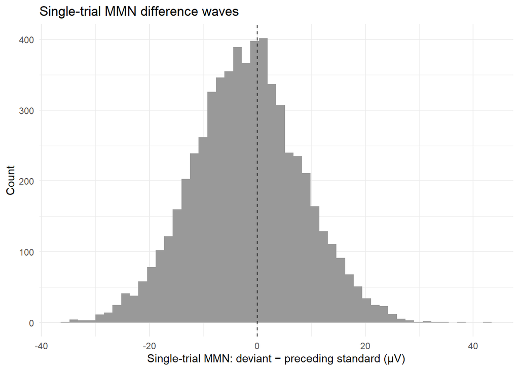

```r
# Distribution of single-trial MMNs
ggplot(mmn_data, aes(x = MMN)) +
  geom_histogram(bins = 50, fill = "grey60") +
  geom_vline(xintercept = 0, linetype = "dashed") +
  theme_minimal() +
  labs(x = "Single-trial MMN: deviant − preceding standard (µV)", y = "Count",
       title = "Single-trial MMN difference waves")
```

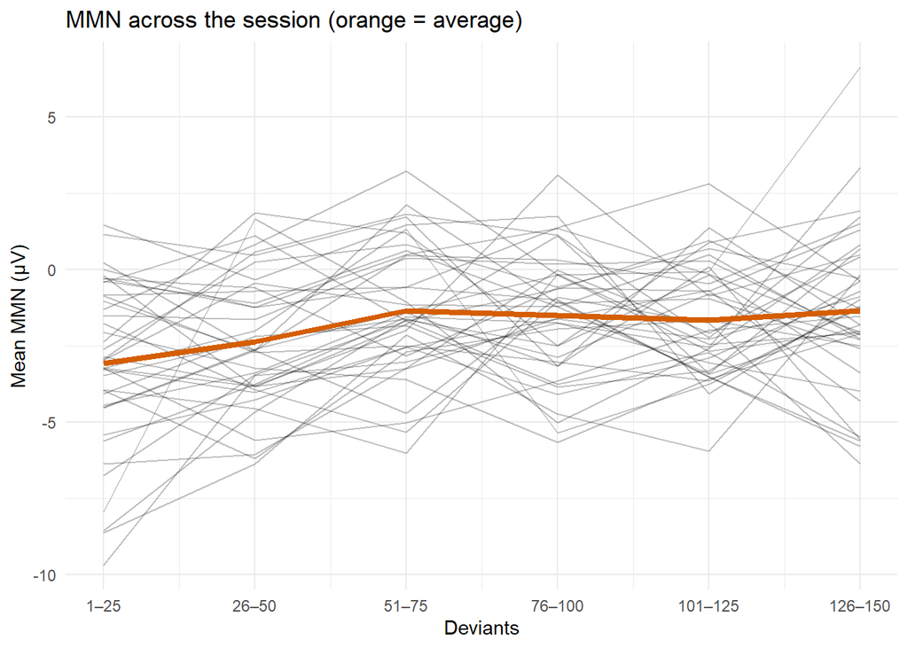

```r
# Each participant's MMN across the session (averaged in blocks of 25 deviants)
mmn_data %>%
  mutate(Block = ceiling(DevNum / 25)) %>%
  group_by(SubjectID, Block) %>%
  summarise(MMN = mean(MMN), .groups = "drop") %>%
  ggplot(aes(x = Block, y = MMN, group = SubjectID)) +
  geom_line(alpha = 0.25) +
  stat_summary(aes(group = 1), fun = mean, geom = "line", linewidth = 1.5, color = "#D55E00") +
  scale_x_continuous(breaks = 1:6, labels = paste0(seq(1, 126, 25), "–", seq(25, 150, 25))) +
  theme_minimal() +
  labs(x = "Deviants", y = "Mean MMN (µV)",
       title = "MMN across the session (orange = average)")
```

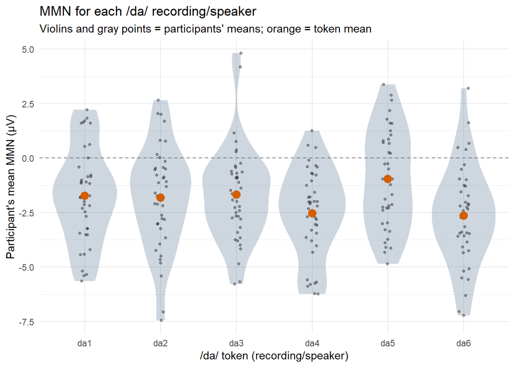

```r
# MMN for each /da/ token: each participant's mean MMN for that token
mmn_data %>%
  group_by(SubjectID, Token) %>%
  summarise(MMN = mean(MMN), .groups = "drop") %>%
  ggplot(aes(x = Token, y = MMN)) +
  geom_hline(yintercept = 0, linetype = "dashed", color = "grey50") +
  geom_violin(fill = "#3D6080", alpha = 0.25, color = NA) +
  geom_jitter(width = 0.08, alpha = 0.35, size = 1) +
  stat_summary(fun = mean, geom = "point", size = 3.5, color = "#D55E00") +
  theme_minimal() +
  labs(x = "/da/ token (recording/speaker)", y = "Participant's mean MMN (µV)",
       title = "MMN for each /da/ recording/speaker",
       subtitle = "Violins and gray points = participants' means; orange = token mean")
```

# 4 Fitting an LME: the 9 steps

## 4.1 Step 1: Define the research question

Does the MMN change with age?

## 4.2 Step 2: List all relevant variables

- `MMN`: single-trial difference wave (deviant − preceding standard), the outcome
- `AgeYears`: participant’s age
- `DevNum`: presentation number of the deviant (1st, 2nd, … 150th)
- `SubjectID`: participant
- `Token`: which /da/ recording/speaker was played

## 4.3 Step 3: Draw the study design schematic

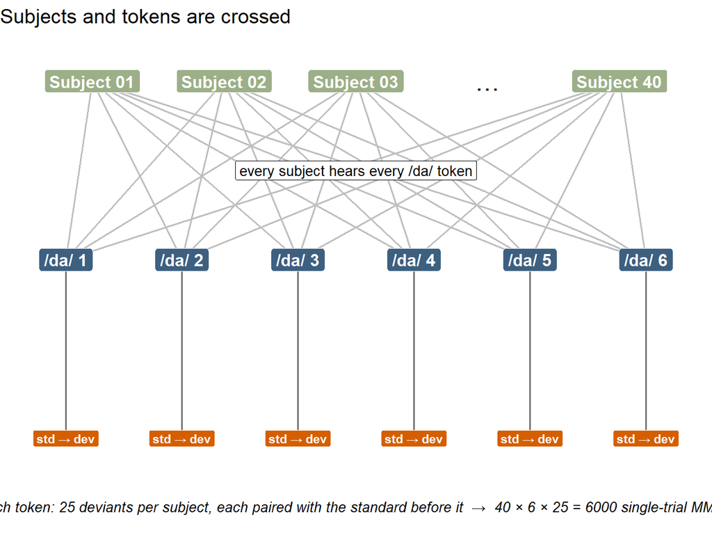

```r
subj_nodes  <- tibble(label = c("Subject 01", "Subject 02", "Subject 03", "…",
                                paste("Subject", n_subjects)),
                      x = 1:5, y = 2)
token_nodes <- tibble(label = paste0("/da/ ", 1:n_tokens),
                      x = seq(0.8, 5.2, length.out = n_tokens), y = 1)
pair_nodes  <- token_nodes %>% mutate(y = 0, label = "std → dev")
edges <- expand_grid(x = subj_nodes$x[subj_nodes$label != "…"],
                     xend = token_nodes$x)

ggplot() +
  geom_segment(data = edges, aes(x = x, xend = xend, y = 2, yend = 1), colour = "grey75") +
  geom_segment(data = token_nodes, aes(x = x, xend = x, y = 1, yend = 0), colour = "grey45") +
  geom_label(data = filter(subj_nodes, label != "…"), aes(x, y, label = label),
             fill = "#9CAF88", colour = "white", fontface = "bold") +
  geom_text(data = filter(subj_nodes, label == "…"), aes(x, y, label = label), size = 6) +
  geom_label(data = token_nodes, aes(x, y, label = label),
             fill = "#3D6080", colour = "white", fontface = "bold") +
  geom_label(data = pair_nodes, aes(x, y, label = label),
             fill = "#D55E00", colour = "white", fontface = "bold", size = 3) +
  annotate("label", x = 3, y = 1.5, fill = "white", size = 3.5,
           label = "every subject hears every /da/ token") +
  annotate("text", x = 3, y = -0.38, size = 3.5, fontface = "italic",
           label = paste0("each token: ", dev_per_token,
                          " deviants per subject, each paired with the standard before it  →  ",
                          n_subjects, " × ", n_tokens, " × ", dev_per_token, " = ",
                          n_subjects * n_deviant, " single-trial MMNs")) +
  labs(title = "Subjects and tokens are crossed") +
  scale_x_continuous(expand = expansion(add = 0.5)) +
  scale_y_continuous(expand = expansion(add = 0.3)) +
  theme_void(base_size = 12)
```

## 4.4 Step 4: Categorize variables by type & level (trial vs. subject)

- `MMN`: continuous, trial-level (outcome)
- `AgeYears`: continuous, participant-level
- `DevNum`: continuous, trial-level
- `Token`: categorical, trial-level (grouping factor: a sample of possible recordings/speakers)
- `SubjectID`: categorical, participant-level (grouping factor)

## 4.5 Step 5: Assign fixed and random effects

### 4.5.1 Fixed effects

- Age (our research question)
- Presentation number (a covariate: the MMN may habituate over the session)

### 4.5.2 Possible random effects in our design

*SubjectID*

- `(1 | SubjectID)`: Do participants differ in the size of their MMN?
- `(1 + DevNum | SubjectID)`: Do participants habituate at different rates?

*Token*

- `(1 | Token)`: Do some /da/ recordings/speakers elicit a larger MMN than others?
- `(1 + DevNum | Token)`: Does the MMN habituate faster for some recordings/speakers?
- `(1 + Age | Token)`: Does the age effect differ across recordings/speakers?

There is no `(1 + Age | SubjectID)`: each participant has only one age, so participants can’t differ in an age effect.

### 4.5.3 Two possible maximal models

The maximal model depends on your hypothesis. Either of these is reasonable:

**A. Habituation is the same at every age.** Presentation number and age are separate fixed effects:

```
MMN ~ DevNum_gmc + Age_gmc +
      (1 + DevNum_gmc | SubjectID) +
      (1 + DevNum_gmc + Age_gmc | Token)
```

**B. The habituation rate changes with age.** If you expected older children’s MMNs to fade faster (or slower) over the session, you would add the **DevNum × Age interaction**. Random slopes only include terms that are in the fixed effects, so the by-token slopes get the interaction too (tokens could differ in how much age changes habituation). Participants still get only a habituation slope, because each has one age:

```
MMN ~ DevNum_gmc * Age_gmc +
      (1 + DevNum_gmc | SubjectID) +
      (1 + DevNum_gmc * Age_gmc | Token)
```

Our research question is about the age effect on the MMN, not whether habituation changes with age, so **we fit Model A**. With Model B, the by-token interaction slope would be the first thing to remove in Step 7: it’s the least plausible, and with only six tokens it can’t be estimated.

## 4.6 Step 6: Consider data transformations & center predictors

**Rescale presentation number.** `DevNum` runs from 1 to 150, so its slope (µV per deviant) is tiny, and random-slope SDs on that scale are tiny too. Very small variance components make the model hard to estimate, and `lme4` may warn that predictors are on very different scales. We express it in **units of 10 deviants**, so the habituation slope is “µV per 10 deviants”.

**Center** both predictors, so the intercept is the MMN in the middle of the session for a participant of average age:

```r
age_grandmean <- mean(distinct(mmn_data, SubjectID, AgeYears)$AgeYears)   # one value per participant

mmn_data <- mmn_data %>%
  mutate(DevNum_gmc = (DevNum - mean(DevNum)) / 10,   # grand-mean centered, in units of 10 deviants
         Age_gmc    = AgeYears - age_grandmean)         # grand-mean centered age

mmn_data %>% select(SubjectID, Token, DevNum, DevNum_gmc, AgeYears, Age_gmc, MMN) %>% head()
```

```
## # A tibble: 6 × 7
##   SubjectID Token DevNum DevNum_gmc AgeYears Age_gmc    MMN
##   <chr>     <chr>  <int>      <dbl>    <dbl>   <dbl>  <dbl>
## 1 01        da1        1      -7.45      3.9   0.802   5.38
## 2 01        da5        2      -7.35      3.9   0.802   8.12
## 3 01        da2        3      -7.25      3.9   0.802   1.18
## 4 01        da5        4      -7.15      3.9   0.802  16.9
## 5 01        da1        5      -7.05      3.9   0.802  -5.60
## 6 01        da4        6      -6.95      3.9   0.802 -14.6
```

There’s no condition variable to code because we’ve already subtracted deviant - standard. We’ll come back to what coding would mean if you modeled the standards and deviants directly (see the supplement, `LME_ex2_supplement_interaction.Rmd`).

## 4.7 Step 7: Fit the maximal model and simplify until convergence is reached

As in Example 1, we start from the maximal model and simplify it **one random effect at a time**, using a “leave-one-out” approach: remove one random effect, refit, and check the fit. If that doesn’t fix the problem, put it back and remove the matching random effect for the other grouping factor instead. If neither version converges without a singular fit, remove both and move on. We work through them in this order:

1. **The by-token age slope first (Round 1):** it’s the least plausible (do tokens differ in how the MMN changes with age?) and the hardest to estimate with only 6 tokens. There’s no participant version to try: each participant has only one age.
2. **Then the habituation slopes (Round 2):** the by-token slope before the by-participant slope. With only 6 tokens there’s the least information to estimate how tokens differ, and how participants differ in habituation is something we’d like to keep.
3. **Until we reach random intercepts only,** or stop earlier as soon as a model converges without a singular fit.

At each step, we check:

- **Estimation warnings:** Is the fit singular or non-converging (`isSingular()`, `check_convergence()`)?
- **Variance components:** In `VarCorr()` output, look for random-effect SDs near zero and correlations near ±1.

```r
check_fit <- function(fit) {
  cat("Singular fit:", isSingular(fit), "\n\n")
  print(VarCorr(fit), comp = "Std.Dev.")  # random-effect SDs and correlations
}
```

### 4.7.1 Step 7a: Fit the maximal model

```r
fit_max <- lmer(MMN ~ DevNum_gmc + Age_gmc +
                  (1 + DevNum_gmc | SubjectID) +          # participants differ in MMN size and habituation
                  (1 + DevNum_gmc + Age_gmc | Token),     # tokens differ in MMN size, habituation, age effect
                data = mmn_data)

check_fit(fit_max)
```

```
## Singular fit: TRUE
##
##  Groups    Name        Std.Dev. Corr
##  SubjectID (Intercept) 1.040158
##            DevNum_gmc  0.212855 -0.436
##  Token     (Intercept) 0.548754
##            DevNum_gmc  0.097224 -1.000
##            Age_gmc     0.133656  1.000 -1.000
##  Residual              9.934522
```

**What do the variance components tell us?**

- **Token:** the slope SDs are small and the correlations are at ±1. With only 6 tokens, there isn’t enough information to estimate how tokens differ in habituation or age effects.
- **SubjectID:** the habituation slope SD isn’t near 0, and the correlation isn’t at ±1.

### 4.7.2 Leave-one-out approach

Here’s every model we would fit along the way. Some are in code chunks below so you can see the output.

**Round 1: the by-token age slope** (starting from the maximal model, Step 7a)

- Remove the by-token age slope: `(1 + DevNum_gmc | SubjectID) + (1 + DevNum_gmc | Token)` → still singular: the by-token habituation slope is tiny and correlated −1 with the token intercept (shown below as `fit_7b`).

**Round 2: the habituation slopes**

- Remove the by-token habituation slope: `(1 + DevNum_gmc | SubjectID) + (1 | Token)` → not singular. lme4 gives a borderline convergence warning, but if we use a better optimizer you’ll see the model converges! (shown below as `fit_7c`): **this is our final random-effects structure**, so we stop here.
- *If that hadn’t worked*, we would put it back and remove the by-participant habituation slope instead: `(1 | SubjectID) + (1 + DevNum_gmc | Token)` → this one is singular (the by-token slope is again correlated −1 with the intercept), so it wouldn’t have been an option anyway.
- *And if neither had worked*, we would remove both: `(1 | SubjectID) + (1 | Token)` (random intercepts only).

### 4.7.3 Step 7b: Remove the by-token age slope

```r
fit_7b <- lmer(MMN ~ DevNum_gmc + Age_gmc +
                 (1 + DevNum_gmc | SubjectID) +
                 (1 + DevNum_gmc | Token),
               data = mmn_data)

check_fit(fit_7b)
```

```
## Singular fit: TRUE
##
##  Groups    Name        Std.Dev. Corr
##  SubjectID (Intercept) 1.039523
##            DevNum_gmc  0.213047 -0.436
##  Token     (Intercept) 0.546609
##            DevNum_gmc  0.097456 -1.000
##  Residual              9.934760
```

Still singular: the by-token habituation slope SD is only 0.1 µV, and its correlation with the token intercept is -1. On to Round 2.

### 4.7.4 Step 7c: Remove the by-token habituation slope

```r
fit_7c <- lmer(MMN ~ DevNum_gmc + Age_gmc +
                 (1 + DevNum_gmc | SubjectID) +
                 (1 | Token),
               data = mmn_data)
```

```
## Warning in checkConv(attr(opt, "derivs"), opt$par, ctrl = control$checkConv, : Model failed to converge with max|grad|
## = 0.00286211 (tol = 0.002, component 1)
```

```r
check_fit(fit_7c)
```

```
## Singular fit: FALSE
##
##  Groups    Name        Std.Dev. Corr
##  SubjectID (Intercept) 1.03366
##            DevNum_gmc  0.21322  -0.448
##  Token     (Intercept) 0.52497
##  Residual              9.94366
```

The fit isn’t singular, and the variance components look reasonable. But lme4 warns that the model “failed to converge”: the gradient at the solution (max|grad|) is just above lme4’s tolerance of 0.002. **Before simplifying further, check whether the warning is a false alarm:** refit with a different optimizer and compare the estimates.

```r
fit_rm_token_slopes <- lmer(MMN ~ DevNum_gmc + Age_gmc +
                              (1 + DevNum_gmc | SubjectID) +
                              (1 | Token),
                            data = mmn_data,
                            control = lmerControl(optimizer = "bobyqa"))

check_fit(fit_rm_token_slopes)
```

```
## Singular fit: FALSE
##
##  Groups    Name        Std.Dev. Corr
##  SubjectID (Intercept) 1.03357
##            DevNum_gmc  0.21322  -0.447
##  Token     (Intercept) 0.52506
##  Residual              9.94366
```

```r
performance::check_convergence(fit_rm_token_slopes)
```

```
## [1] TRUE
## attr(,"gradient")
## [1] 1.702345e-07
```

```r
# Same estimates with both optimizers?
round(cbind(default = fixef(fit_7c), bobyqa = fixef(fit_rm_token_slopes)), 3)
```

```
##             default bobyqa
## (Intercept)  -1.892 -1.892
## DevNum_gmc    0.124  0.124
## Age_gmc      -0.084 -0.083
```

With the bobyqa optimizer there’s no warning, and the estimates are the same! (For a more thorough check, `allFit(fit_7c)` refits the model with every available optimizer.) This model converges without a singular fit, so we stop simplifying here.

### 4.7.5 Step 7d: Is the participant habituation slope supported?

If we were still concerned that our data didn’t support by-subject slopes for deviant number (presentation number), we can compare models using the likelihood ratio test (LRT). As a reminder, the χ² is the difference in deviance, and its df is the number of extra parameters (here 2: the slope’s SD and its correlation with the intercept). A significant p means the extra term improves the fit. These two models differ only in their random effects, so we add refit = FALSE to keep REML (when models differ in their fixed effects, anova() refits both with ML automatically).

```r
fit_no_subject_slope <- lmer(MMN ~ DevNum_gmc + Age_gmc + (1 | SubjectID) + (1 | Token),
                             data = mmn_data)
anova(fit_no_subject_slope, fit_rm_token_slopes, refit = FALSE)
```

```
## Data: mmn_data
## Models:
## fit_no_subject_slope: MMN ~ DevNum_gmc + Age_gmc + (1 | SubjectID) + (1 | Token)
## fit_rm_token_slopes: MMN ~ DevNum_gmc + Age_gmc + (1 + DevNum_gmc | SubjectID) + (1 | Token)
##                      npar   AIC   BIC logLik deviance  Chisq Df Pr(>Chisq)
## fit_no_subject_slope    6 44701 44742 -22345    44689
## fit_rm_token_slopes     8 44685 44738 -22334    44669 20.533  2  3.478e-05 ***
## ---
## Signif. codes:  0 '***' 0.001 '**' 0.01 '*' 0.05 '.' 0.1 ' ' 1
```

The random slope improves the fit, so we keep it and now fit_final is our final model that we will interpret:

```r
fit_final <- fit_rm_token_slopes
```

### 4.7.6 Describing the simplification in your methods

*“We began with the maximal random-effects structure (Barr et al., 2013) and simplified it one term at a time until the model converged without a singular fit, starting with the by-token random slopes (only six tokens): first the by-token slope of age, then the by-token slope of presentation number. The final model, fit with the bobyqa optimizer, included by-participant random intercepts and random slopes of presentation number, a by-token random intercept, and fixed effects of presentation number (grand-mean centered, in units of 10 deviants) and age (grand-mean centered).”

You could also add: “A likelihood-ratio test supported keeping the by-participant slope (χ²(2) = 20.53, *p* < .001).”*

## 4.8 Step 8: Check model assumptions

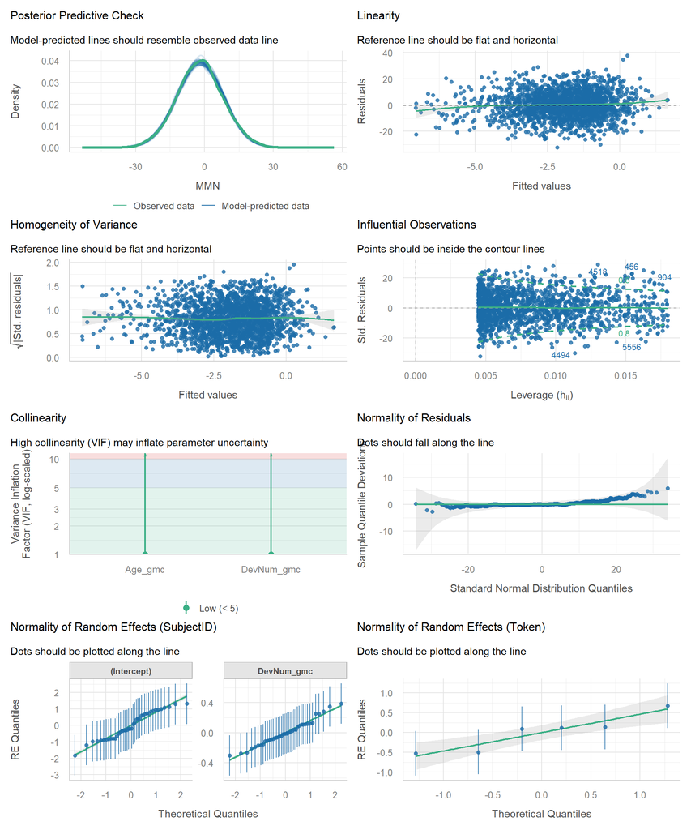

```r
check_model(fit_final)
```

With 6,000 single-trial MMNs, formal tests (e.g., Shapiro-Wilk for normality or a test for heteroscedasticity) can be significant even when there are only small deviations from the assumption. Some researchers recommend Shapiro-Wilk for samples up to 5,000 but other researchers suggest that Shapiro-Wilk is too sensitive even lower (e.g., at 4,000 observations). Beyond 4,000-5,000 observations/total trials you should use visual inspection: flat reference lines (linearity, homogeneity of variance), dots along the line (normality of residuals and random effects), and points inside the contour lines (influential observations).

**The collinearity panel can look strange with only two predictors**, so print the VIFs directly:

```r
check_collinearity(fit_final)
```

```
## # Check for Multicollinearity
##
## Low Correlation
##
##        Term  VIF  VIF 95% CI adj. VIF Tolerance Tolerance 95% CI
##  DevNum_gmc 1.00 [1.00, Inf]     1.00      1.00     [0.00, 1.00]
##     Age_gmc 1.00 [1.00, Inf]     1.00      1.00     [0.00, 1.00]
```

Both VIFs are close to 1: age and presentation number are centered, and age varies between participants while presentation number varies within them, so the two predictors don’t overlap.

## 4.9 Step 9: Interpret and visualize results

### 4.9.1 Interpreting the model output

```r
summary(fit_final)
```

```
## Linear mixed model fit by REML. t-tests use Satterthwaite's method ['lmerModLmerTest']
## Formula: MMN ~ DevNum_gmc + Age_gmc + (1 + DevNum_gmc | SubjectID) + (1 |      Token)
##    Data: mmn_data
## Control: lmerControl(optimizer = "bobyqa")
##
## REML criterion at convergence: 44668.8
##
## Scaled residuals:
##     Min      1Q  Median      3Q     Max
## -3.2577 -0.6588 -0.0077  0.6475  4.4348
##
## Random effects:
##  Groups    Name        Variance Std.Dev. Corr
##  SubjectID (Intercept)  1.06828 1.0336
##            DevNum_gmc   0.04546 0.2132   -0.45
##  Token     (Intercept)  0.27569 0.5251
##  Residual              98.87638 9.9437
## Number of obs: 6000, groups:  SubjectID, 40; Token, 6
##
## Fixed effects:
##             Estimate Std. Error       df t value Pr(>|t|)
## (Intercept) -1.89230    0.29856  9.57317  -6.338 0.000103 ***
## DevNum_gmc   0.12374    0.04490 38.96249   2.756 0.008856 **
## Age_gmc     -0.08337    0.38238 37.99886  -0.218 0.828576
## ---
## Signif. codes:  0 '***' 0.001 '**' 0.01 '*' 0.05 '.' 0.1 ' ' 1
##
## Correlation of Fixed Effects:
##            (Intr) DvNm_g
## DevNum_gmc -0.184
## Age_gmc     0.000  0.000
```

```r
tab_model(fit_final)
```

|  | MMN |  |  |
| --- | --- | --- | --- |
| Predictors | Estimates | CI | p |
| (Intercept) | -1.89 | -2.48 – -1.31 | **<0.001** |
| DevNum gmc | 0.12 | 0.04 – 0.21 | **0.006** |
| Age gmc | -0.08 | -0.83 – 0.67 | 0.827 |
| Random Effects |  |  |  |
| σ<sup>2</sup> | 98.88 |  |  |
| τ<sub>00</sub> <sub>SubjectID</sub> | 1.07 |  |  |
| τ<sub>00</sub> <sub>Token</sub> | 0.28 |  |  |
| τ<sub>11</sub> <sub>SubjectID.DevNum_gmc</sub> | 0.05 |  |  |
| ρ<sub>01</sub> <sub>SubjectID</sub> | -0.45 |  |  |
| ICC | 0.02 |  |  |
| N <sub>SubjectID</sub> | 40 |  |  |
| N <sub>Token</sub> | 6 |  |  |
| Observations | 6000 |  |  |
| Marginal R<sup>2</sup> / Conditional R<sup>2</sup> | 0.003 / 0.025 |  |  |

```r
b        <- fixef(fit_final)
vc_subj  <- VarCorr(fit_final)$SubjectID
sd_mmn   <- attr(vc_subj, "stddev")[["(Intercept)"]]
sd_hab   <- attr(vc_subj, "stddev")[["DevNum_gmc"]]
cor_mh   <- attr(vc_subj, "correlation")[1, 2]
sd_token <- attr(VarCorr(fit_final)$Token, "stddev")[["(Intercept)"]]
sd_resid <- sigma(fit_final)
coefs    <- summary(fit_final)$coefficients
```

### 4.9.2 Fixed effects

- **Age_gmc = -0.08 µV:** the change in the MMN per year of age (simulated: -0.5 µV; p = 0.83). This answers our research question: there’s no evidence that the MMN changes with age here. Age is a participant-level predictor tested against only 40 participants (df ≈ 38), so a modest age effect is hard to detect.
- **(Intercept) = -1.89 µV:** the MMN in the middle of the session for a participant of average age (simulated: -1.9 µV). Look at its df (≈ 10): the average MMN has to generalize across participants *and* across the 6 tokens, so with few tokens, its df is small (like the actors in Example 1).
- **DevNum_gmc = 0.12 µV:** the MMN becomes 0.12 µV less negative with every 10 deviants (simulated: 0.15), so it weakens over the session (habituation). Over all 150 deviants, that’s about 1.9 µV. Its df is about 39: with a random slope, habituation is tested against how much participants differ in it.

### 4.9.3 Random effects

- **Participants’ MMN, SD = 1.03 µV** (simulated: 1.15): participants’ MMNs typically differ from the average by about 1 µV. About 97% of participants are expected to show an MMN (a negative difference) in the middle of the session.
- **Participants’ habituation, SD = 0.21 µV per 10 deviants** (simulated: 0.2): some participants’ MMNs fade quickly; others barely change.
- **Correlation = -0.45:** between participants’ MMN and their habituation (we simulated 0). With 40 participants, this is estimated imprecisely.
- **Tokens, SD = 0.53 µV** (simulated: 0.5): some /da/ recordings/speakers elicit a larger MMN than others.
- **Residual SD = 9.94 µV:** single-trial noise in the difference wave (about √2 × 7 = 9.9 µV, because each MMN contains the noise from two trials).

### 4.9.4 Visualizing the results

I prefer plotting the model’s estimated marginal means (EMMs) for the fixed effects of interest, rather than raw averages, because when we report our models we’re reporting the model estimates (not the raw averages). When it’s possible, it’s nice to show participant averages or trial-level variability so that readers get a sense of the means and spread of the data. Our model has a random slope, so we also show how participants differ in their habituation.

**Our research question: the MMN across age.** Each point is one participant’s mean MMN; the line is the model’s estimate:

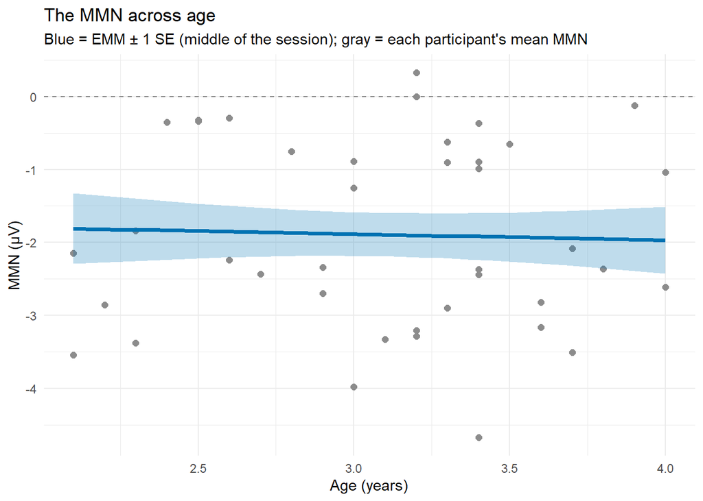

```r
# Model-estimated MMN across the observed age range (middle of the session), ± 1 SE
age_grid <- seq(min(mmn_data$Age_gmc), max(mmn_data$Age_gmc), length.out = 25)
emm_age <- emmeans(fit_final, ~ Age_gmc, at = list(Age_gmc = age_grid),
                   lmer.df = "asymptotic")

subject_age_means <- mmn_data %>%
  group_by(SubjectID, AgeYears) %>%
  summarise(MMN = mean(MMN), .groups = "drop")

as.data.frame(emm_age) %>%
  mutate(AgeYears = Age_gmc + age_grandmean) %>%          # back to years for the x-axis
  ggplot(aes(x = AgeYears, y = emmean)) +
  geom_hline(yintercept = 0, linetype = "dashed", color = "grey50") +
  geom_point(data = subject_age_means, aes(y = MMN), color = "grey55", size = 2) +
  geom_ribbon(aes(ymin = emmean - SE, ymax = emmean + SE), fill = "#0072B2", alpha = 0.25) +
  geom_line(color = "#0072B2", linewidth = 1.3) +
  theme_minimal() +
  labs(x = "Age (years)", y = "MMN (µV)",
       title = "The MMN across age",
       subtitle = "Blue = EMM ± 1 SE (middle of the session); gray = each participant's mean MMN")
```

**Habituation, with each participant’s line** (the random slope):

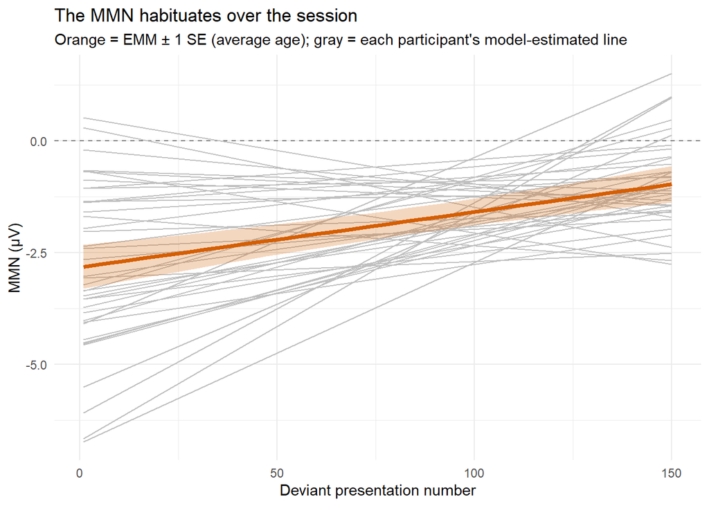

```r
# Model-estimated MMN across the session (for a participant of average age), ± 1 SE
dev_grid <- seq(min(mmn_data$DevNum_gmc), max(mmn_data$DevNum_gmc), length.out = 30)
emm_dev <- emmeans(fit_final, ~ DevNum_gmc, at = list(DevNum_gmc = dev_grid),
                   lmer.df = "asymptotic")

# Each participant's model-estimated line (fixed effects + their random intercept and slope)
subject_lines <- coef(fit_final)$SubjectID %>%
  rownames_to_column("SubjectID") %>%
  transmute(SubjectID, intercept = `(Intercept)`, slope = DevNum_gmc) %>%
  crossing(x = range(mmn_data$DevNum_gmc)) %>%
  mutate(MMN = intercept + slope * x)

back_to_devnum <- function(x) x * 10 + mean(mmn_data$DevNum)   # back to 1-150 for the x-axis

as.data.frame(emm_dev) %>%
  ggplot(aes(x = back_to_devnum(DevNum_gmc), y = emmean)) +
  geom_hline(yintercept = 0, linetype = "dashed", color = "grey50") +
  geom_line(data = subject_lines, aes(x = back_to_devnum(x), y = MMN, group = SubjectID),
            color = "grey75", linewidth = 0.4) +
  geom_ribbon(aes(ymin = emmean - SE, ymax = emmean + SE), fill = "#D55E00", alpha = 0.25) +
  geom_line(color = "#D55E00", linewidth = 1.3) +
  theme_minimal() +
  labs(x = "Deviant presentation number", y = "MMN (µV)",
       title = "The MMN habituates over the session",
       subtitle = "Orange = EMM ± 1 SE (average age); gray = each participant's model-estimated line")
```

**Plotting the random slopes.** The gray lines above show the random slopes as lines; we can also plot each participant’s estimated habituation slope directly. `ranef()` gives each participant’s deviation from the fixed effect (their random effect) and, with `condVar = TRUE`, how uncertain it is. Adding the fixed effect back gives each participant’s own slope. This kind of plot is often called a **caterpillar plot**:

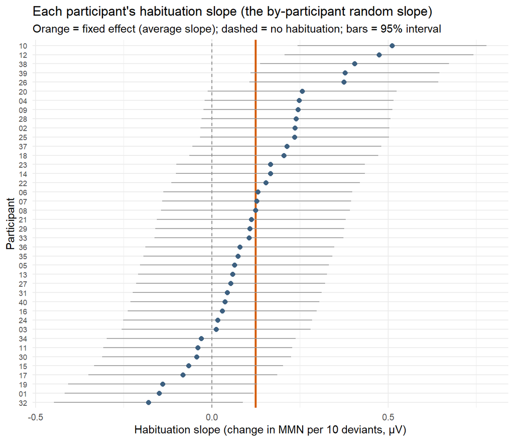

```r
# Each participant's random intercept and slope, + the fixed effects = their own MMN and habituation slope
subject_re_est <- as.data.frame(ranef(fit_final, condVar = TRUE)) %>%
  filter(grpvar == "SubjectID") %>%
  mutate(estimate = condval + fixef(fit_final)[as.character(term)],   # fixed effect + random effect
         lower    = estimate - 1.96 * condsd,                          # 95% interval of each participant's estimate
         upper    = estimate + 1.96 * condsd)

hab_slopes <- subject_re_est %>%
  filter(term == "DevNum_gmc") %>%
  mutate(SubjectID = fct_reorder(grp, estimate))                      # order participants by their slope

ggplot(hab_slopes, aes(x = estimate, y = SubjectID)) +
  geom_vline(xintercept = 0, linetype = "dashed", color = "grey50") +
  geom_vline(xintercept = fixef(fit_final)[["DevNum_gmc"]], color = "#D55E00", linewidth = 1) +
  geom_errorbarh(aes(xmin = lower, xmax = upper), height = 0, color = "grey60") +
  geom_point(color = "#3D6080", size = 2) +
  theme_minimal() +
  theme(axis.text.y = element_text(size = 7)) +
  labs(x = "Habituation slope (change in MMN per 10 deviants, µV)", y = "Participant",
       title = "Each participant's habituation slope (the by-participant random slope)",
       subtitle = "Orange = fixed effect (average slope); dashed = no habituation; bars = 95% interval")
```

Because the random intercept and slope are correlated, it’s also worth plotting them against each other: do participants with larger MMNs habituate more or less?

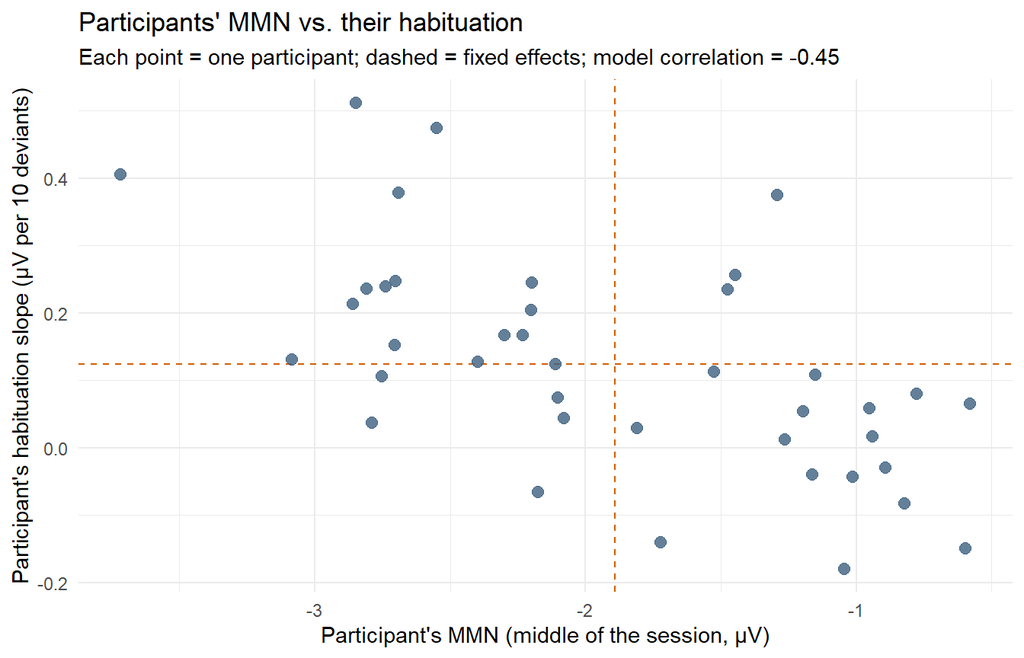

```r
subject_re_est %>%
  select(SubjectID = grp, term, estimate) %>%
  pivot_wider(names_from = term, values_from = estimate) %>%
  ggplot(aes(x = `(Intercept)`, y = DevNum_gmc)) +
  geom_hline(yintercept = fixef(fit_final)[["DevNum_gmc"]], color = "#D55E00", linetype = "dashed") +
  geom_vline(xintercept = fixef(fit_final)[["(Intercept)"]], color = "#D55E00", linetype = "dashed") +
  geom_point(color = "#3D6080", size = 2.5, alpha = 0.8) +
  theme_minimal() +
  labs(x = "Participant's MMN (middle of the session, µV)",
       y = "Participant's habituation slope (µV per 10 deviants)",
       title = "Participants' MMN vs. their habituation",
       subtitle = paste0("Each point = one participant; dashed = fixed effects; model correlation = ",
                         round(attr(VarCorr(fit_final)$SubjectID, "correlation")[1, 2], 2)))
```

**Two more figures for a paper:**

- **The grand-average difference wave** (and the standard and deviant waveforms it came from), averaged across all participants with no casewise deletion. Our simulation only has mean amplitudes, so we can’t plot it here.
- **Single-trial waveforms from an example participant**, to show variability in single-trial data (can also go in Supplement for publications).

# 5 About these materials

These materials were developed for the Society for Psychophysiological Research pre-conference workshop “Linear mixed effects models for event-related potential research” (October 14, 2026, Halifax, Canada) by Megan J. Heise.

**Please cite as:** Heise, M. J. (2026, October 14). *Linear mixed effects models for event-related potential research* [Workshop materials]. Society for Psychophysiological Research Annual Meeting, Halifax, Nova Scotia, Canada.

# 6 References

Barr, D. J., Levy, R., Scheepers, C., & Tily, H. J. (2013). Random effects structure for confirmatory hypothesis testing: Keep it maximal. *Journal of Memory and Language, 68*(3), 255–278.

Coy, N., Bendixen, A., Grimm, S., Roeber, U., & Schröger, E. (2024). Conditional deviant repetition in the oddball paradigm modulates processing at the level of P3a but not MMN. *Psychophysiology, 61*, e14545. https://doi.org/10.1111/psyp.14545

Heise, M. J., Mon, S. K., & Bowman, L. C. (2022). Utility of linear mixed effects models for event-related potential research with infants and children. *Developmental Cognitive Neuroscience, 54*, 101070. https://doi.org/10.1016/j.dcn.2022.101070

Heise, M. J., Mon, S. K., & Bowman, L. C. (2025). Analysis of event-related potential difference waves can benefit from linear mixed effects modeling: Recommendations for analyses and general model fitting. *Developmental Cognitive Neuroscience, 76*, 101614. https://doi.org/10.1016/j.dcn.2025.101614

Mon, S. K., Manning, B. L., Wakschlag, L. S., & Norton, E. S. (2024). Leveraging mixed-effects location scale models to assess the ERP mismatch negativity’s psychometric properties and trial-by-trial neural variability in toddler-mother dyads. *Developmental Cognitive Neuroscience, 70*, 101459.